# Convolutional Neural Networks for Text Classification

Github: https://github.com/dennybritz/cnn-text-classification-tf

Paper: https://arxiv.org/pdf/1408.5882.pdf

## Task Introduction

### Input

A sentence in the format of a string from the movie comments.

Eg. 1: "a thoughtful , provocative , insistently humanizing film . "

Eg. 2: "the effort is sincere and the results are honest , but the film is so bleak that it's hardly watchable ."

### Output

A binary sentiment classification result of the input sentence, 0 indicates negative and 1 indicates positive.

Eg. 1: 1 (positive)

Eg. 2: 0 (negative)

```python
import os
for dirname, _, filenames in os.walk('/kaggle/input'):
    for filename in filenames:
        print(os.path.join(dirname, filename))
```

```
/kaggle/input/textclassification/rt-polarity.pos
/kaggle/input/textclassification/rt-polarity.neg
```

```python
f = open("/kaggle/input/textclassification/rt-polarity.neg", "r", encoding='utf-8')
a = f.readlines()
print(len(a))
for i in range(10):
    print(a[i])
```

```
5331
simplistic , silly and tedious .

it's so laddish and juvenile , only teenage boys could possibly find it funny .

exploitative and largely devoid of the depth or sophistication that would make watching such a graphic treatment of the crimes bearable .

[garbus] discards the potential for pathological study , exhuming instead , the skewed melodrama of the circumstantial situation .

a visually flashy but narratively opaque and emotionally vapid exercise in style and mystification .

the story is also as unoriginal as they come , already having been recycled more times than i'd care to count .

about the only thing to give the movie points for is bravado -- to take an entirely stale concept and push it through the audience's meat grinder one more time .

not so much farcical as sour .

unfortunately the story and the actors are served with a hack script .

all the more disquieting for its relatively gore-free allusions to the serial murders , but it falls down in its attempts to humanize its subject .
```

### Data Helpers

```python
import numpy as np
import re


def clean_str(string):
    """
    Tokenization/string cleaning for all datasets except for SST.
    Original taken from https://github.com/yoonkim/CNN_sentence/blob/master/process_data.py
    """
    string = re.sub(r"[^A-Za-z0-9(),!?\'\`]", " ", string)
    string = re.sub(r"\'s", " \'s", string)
    string = re.sub(r"\'ve", " \'ve", string)
    string = re.sub(r"n\'t", " n\'t", string)
    string = re.sub(r"\'re", " \'re", string)
    string = re.sub(r"\'d", " \'d", string)
    string = re.sub(r"\'ll", " \'ll", string)
    string = re.sub(r",", " , ", string)
    string = re.sub(r"!", " ! ", string)
    string = re.sub(r"\(", " \( ", string)
    string = re.sub(r"\)", " \) ", string)
    string = re.sub(r"\?", " \? ", string)
    string = re.sub(r"\s{2,}", " ", string)
    return string.strip().lower()


def load_data_and_labels(positive_data_file, negative_data_file):
    """
    Loads MR polarity data from files, splits the data into words and generates labels.
    Returns split sentences and labels.
    """
    # Load data from files
    positive_examples = list(open(positive_data_file, "r", encoding='utf-8').readlines())
    positive_examples = [s.strip() for s in positive_examples]
    negative_examples = list(open(negative_data_file, "r", encoding='utf-8').readlines())
    negative_examples = [s.strip() for s in negative_examples]
    # Split by words
    x_text = positive_examples + negative_examples
    x_text = [clean_str(sent) for sent in x_text]
    # Generate labels
    positive_labels = [[0, 1] for _ in positive_examples]
    negative_labels = [[1, 0] for _ in negative_examples]
    y = np.concatenate([positive_labels, negative_labels], 0)
    return [x_text, y]


def batch_iter(data, batch_size, num_epochs, shuffle=True):
    """
    Generates a batch iterator for a dataset.
    """
    data = np.array(data)
    data_size = len(data)
    num_batches_per_epoch = int((len(data)-1)/batch_size) + 1
    for epoch in range(num_epochs):
        # Shuffle the data at each epoch
        if shuffle:
            shuffle_indices = np.random.permutation(np.arange(data_size))
            shuffled_data = data[shuffle_indices]
        else:
            shuffled_data = data
        for batch_num in range(num_batches_per_epoch):
            start_index = batch_num * batch_size
            end_index = min((batch_num + 1) * batch_size, data_size)
            yield shuffled_data[start_index:end_index]
```

## Model Description

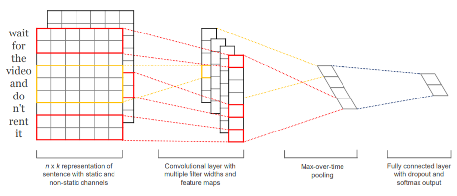

### Embedding Lookup Layer (Line 22 - 28)

You may use Word2vec or GloVe to replace the random initialization.

Tunable hyper parameters:

```
embedding_dim
```

### Convolution Layer (Line 34 - 45)

You may try different nonlinearity other than relu.

Tunable hyper parameters:

```
filter_sizes
num_filters
```

### Max Pooling Layer (Line 46 - 53)

### Fully Connected Layer with Dropout and Softmax Output (Line 60 - 79)

Softmax function:

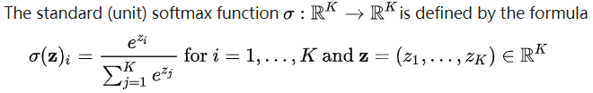

Cross Entropy Loss:

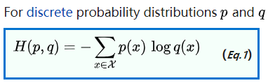

Tunable hyper parameters:

```
dropout_keep_prob (only for training)
l2_reg_lambda
```

```python
import tensorflow as tf
import numpy as np


class TextCNN(object):
    """
    A CNN for text classification.
    Uses an embedding layer, followed by a convolutional, max-pooling and softmax layer.
    """
    def __init__(
      self, sequence_length, num_classes, vocab_size,
      embedding_size, filter_sizes, num_filters, l2_reg_lambda=0.0):

        # Placeholders for input, output and dropout
        self.input_x = tf.placeholder(tf.int32, [None, sequence_length], name="input_x")
        self.input_y = tf.placeholder(tf.float32, [None, num_classes], name="input_y")
        self.dropout_keep_prob = tf.placeholder(tf.float32, name="dropout_keep_prob")

        # Keeping track of l2 regularization loss (optional)
        l2_loss = tf.constant(0.0)

        # Embedding layer
        with tf.device('/cpu:0'), tf.name_scope("embedding"):
            self.W = tf.Variable(
                tf.random_uniform([vocab_size, embedding_size], -1.0, 1.0),
                name="W")
            self.embedded_chars = tf.nn.embedding_lookup(self.W, self.input_x)
            self.embedded_chars_expanded = tf.expand_dims(self.embedded_chars, -1)

        # Create a convolution + maxpool layer for each filter size
        pooled_outputs = []
        for i, filter_size in enumerate(filter_sizes):
            with tf.name_scope("conv-maxpool-%s" % filter_size):
                # Convolution Layer
                filter_shape = [filter_size, embedding_size, 1, num_filters]
                W = tf.Variable(tf.truncated_normal(filter_shape, stddev=0.1), name="W")
                b = tf.Variable(tf.constant(0.1, shape=[num_filters]), name="b")
                conv = tf.nn.conv2d(
                    self.embedded_chars_expanded,
                    W,
                    strides=[1, 1, 1, 1],
                    padding="VALID",
                    name="conv")
                # Apply nonlinearity
                h = tf.nn.relu(tf.nn.bias_add(conv, b), name="relu")
                # Maxpooling over the outputs
                pooled = tf.nn.max_pool(
                    h,
                    ksize=[1, sequence_length - filter_size + 1, 1, 1],
                    strides=[1, 1, 1, 1],
                    padding='VALID',
                    name="pool")
                pooled_outputs.append(pooled)

        # Combine all the pooled features
        num_filters_total = num_filters * len(filter_sizes)
        self.h_pool = tf.concat(pooled_outputs, 3)
        self.h_pool_flat = tf.reshape(self.h_pool, [-1, num_filters_total])

        # Add dropout
        with tf.name_scope("dropout"):
            self.h_drop = tf.nn.dropout(self.h_pool_flat, self.dropout_keep_prob)

        # Final (unnormalized) scores and predictions
        with tf.name_scope("output"):
            W = tf.get_variable(
                "W",
                shape=[num_filters_total, num_classes],
                initializer=tf.contrib.layers.xavier_initializer())
            b = tf.Variable(tf.constant(0.1, shape=[num_classes]), name="b")
            l2_loss += tf.nn.l2_loss(W)
            l2_loss += tf.nn.l2_loss(b)
            self.scores = tf.nn.xw_plus_b(self.h_drop, W, b, name="scores")
            self.predictions = tf.argmax(self.scores, 1, name="predictions")

        # Calculate mean cross-entropy loss
        with tf.name_scope("loss"):
            losses = tf.nn.softmax_cross_entropy_with_logits(logits=self.scores, labels=self.input_y)
            self.loss = tf.reduce_mean(losses) + l2_reg_lambda * l2_loss

        # Accuracy
        with tf.name_scope("accuracy"):
            correct_predictions = tf.equal(self.predictions, tf.argmax(self.input_y, 1))
            self.accuracy = tf.reduce_mean(tf.cast(correct_predictions, "float"), name="accuracy")
```

### Train

Some tunable training hyper parameters which may influence the results:

```
batch_size
num_epochs
optimizer (line 94)
```

All the tunable hyper parameters can be tuned here.

```python
#! /usr/bin/env python

import tensorflow as tf
import numpy as np
import os
import time
import datetime
from tensorflow.contrib import learn

# Parameters
# ==================================================

# Data loading params
tf.flags.DEFINE_float("dev_sample_percentage", .1, "Percentage of the training data to use for validation")
tf.flags.DEFINE_string("positive_data_file", "/kaggle/input/textclassification/rt-polarity.pos", "Data source for the positive data.")
tf.flags.DEFINE_string("negative_data_file", "/kaggle/input/textclassification/rt-polarity.neg", "Data source for the negative data.")

# Model Hyperparameters
tf.flags.DEFINE_integer("embedding_dim", 128, "Dimensionality of character embedding (default: 128)")
tf.flags.DEFINE_string("filter_sizes", "3,4,5", "Comma-separated filter sizes (default: '3,4,5')")
tf.flags.DEFINE_integer("num_filters", 128, "Number of filters per filter size (default: 128)")
tf.flags.DEFINE_float("dropout_keep_prob", 0.5, "Dropout keep probability (default: 0.5)")
tf.flags.DEFINE_float("l2_reg_lambda", 0.0, "L2 regularization lambda (default: 0.0)")

# Training parameters
tf.flags.DEFINE_integer("batch_size", 64, "Batch Size (default: 64)")
tf.flags.DEFINE_integer("num_epochs", 15, "Number of training epochs (default: 20)")
tf.flags.DEFINE_integer("evaluate_every", 100, "Evaluate model on dev set after this many steps (default: 100)")
tf.flags.DEFINE_integer("checkpoint_every", 100, "Save model after this many steps (default: 100)")
tf.flags.DEFINE_integer("num_checkpoints", 5, "Number of checkpoints to store (default: 5)")
# Misc Parameters
tf.flags.DEFINE_boolean("allow_soft_placement", True, "Allow device soft device placement")
tf.flags.DEFINE_boolean("log_device_placement", False, "Log placement of ops on devices")

FLAGS = tf.flags.FLAGS
# FLAGS._parse_flags()
# print("\nParameters:")
# for attr, value in sorted(FLAGS.__flags.items()):
#     print("{}={}".format(attr.upper(), value))
# print("")

timestamp = str(int(time.time()))

def preprocess():
    # Data Preparation
    # ==================================================

    # Load data
    print("Loading data...")
    x_text, y = load_data_and_labels(FLAGS.positive_data_file, FLAGS.negative_data_file)

    # Build vocabulary
    max_document_length = max([len(x.split(" ")) for x in x_text])
    vocab_processor = learn.preprocessing.VocabularyProcessor(max_document_length)
    x = np.array(list(vocab_processor.fit_transform(x_text)))

    # Randomly shuffle data
    np.random.seed(10)
    shuffle_indices = np.random.permutation(np.arange(len(y)))
    x_shuffled = x[shuffle_indices]
    y_shuffled = y[shuffle_indices]

    # Split train/test set
    # TODO: This is very crude, should use cross-validation
    dev_sample_index = -1 * int(FLAGS.dev_sample_percentage * float(len(y)))
    x_train, x_dev = x_shuffled[:dev_sample_index], x_shuffled[dev_sample_index:]
    y_train, y_dev = y_shuffled[:dev_sample_index], y_shuffled[dev_sample_index:]

    del x, y, x_shuffled, y_shuffled

    print("Vocabulary Size: {:d}".format(len(vocab_processor.vocabulary_)))
    print("Train/Dev split: {:d}/{:d}".format(len(y_train), len(y_dev)))
    return x_train, y_train, vocab_processor, x_dev, y_dev

def train(x_train, y_train, vocab_processor, x_dev, y_dev):
    # Training
    # ==================================================

    with tf.Graph().as_default():
        session_conf = tf.ConfigProto(
          allow_soft_placement=FLAGS.allow_soft_placement,
          log_device_placement=FLAGS.log_device_placement)
        sess = tf.Session(config=session_conf)
        with sess.as_default():
            cnn = TextCNN(
                sequence_length=x_train.shape[1],
                num_classes=y_train.shape[1],
                vocab_size=len(vocab_processor.vocabulary_),
                embedding_size=FLAGS.embedding_dim,
                filter_sizes=list(map(int, FLAGS.filter_sizes.split(","))),
                num_filters=FLAGS.num_filters,
                l2_reg_lambda=FLAGS.l2_reg_lambda)

            # Define Training procedure
            global_step = tf.Variable(0, name="global_step", trainable=False)
            optimizer = tf.train.AdamOptimizer(1e-3)
            grads_and_vars = optimizer.compute_gradients(cnn.loss)
            train_op = optimizer.apply_gradients(grads_and_vars, global_step=global_step)

            # Keep track of gradient values and sparsity (optional)
            grad_summaries = []
            for g, v in grads_and_vars:
                if g is not None:
                    grad_hist_summary = tf.summary.histogram("{}/grad/hist".format(v.name), g)
                    sparsity_summary = tf.summary.scalar("{}/grad/sparsity".format(v.name), tf.nn.zero_fraction(g))
                    grad_summaries.append(grad_hist_summary)
                    grad_summaries.append(sparsity_summary)
            grad_summaries_merged = tf.summary.merge(grad_summaries)

            # Output directory for models and summaries
            out_dir = os.path.abspath(os.path.join(os.path.curdir, "runs", timestamp))
            print("Writing to {}\n".format(out_dir))

            # Summaries for loss and accuracy
            loss_summary = tf.summary.scalar("loss", cnn.loss)
            acc_summary = tf.summary.scalar("accuracy", cnn.accuracy)

            # Train Summaries
            train_summary_op = tf.summary.merge([loss_summary, acc_summary, grad_summaries_merged])
            train_summary_dir = os.path.join(out_dir, "summaries", "train")
            train_summary_writer = tf.summary.FileWriter(train_summary_dir, sess.graph)

            # Dev summaries
            dev_summary_op = tf.summary.merge([loss_summary, acc_summary])
            dev_summary_dir = os.path.join(out_dir, "summaries", "dev")
            dev_summary_writer = tf.summary.FileWriter(dev_summary_dir, sess.graph)

            # Checkpoint directory. Tensorflow assumes this directory already exists so we need to create it
            checkpoint_dir = os.path.abspath(os.path.join(out_dir, "checkpoints"))
            checkpoint_prefix = os.path.join(checkpoint_dir, "model")
            if not os.path.exists(checkpoint_dir):
                os.makedirs(checkpoint_dir)
            saver = tf.train.Saver(tf.global_variables(), max_to_keep=FLAGS.num_checkpoints)

            # Write vocabulary
            vocab_processor.save(os.path.join(out_dir, "vocab"))

            # Initialize all variables
            sess.run(tf.global_variables_initializer())

            def train_step(x_batch, y_batch):
                """
                A single training step
                """
                feed_dict = {
                  cnn.input_x: x_batch,
                  cnn.input_y: y_batch,
                  cnn.dropout_keep_prob: FLAGS.dropout_keep_prob
                }
                _, step, summaries, loss, accuracy = sess.run(
                    [train_op, global_step, train_summary_op, cnn.loss, cnn.accuracy],
                    feed_dict)
                time_str = datetime.datetime.now().isoformat()
                print("{}: step {}, loss {:g}, acc {:g}".format(time_str, step, loss, accuracy))
                train_summary_writer.add_summary(summaries, step)

            def dev_step(x_batch, y_batch, writer=None):
                """
                Evaluates model on a dev set
                """
                feed_dict = {
                  cnn.input_x: x_batch,
                  cnn.input_y: y_batch,
                  cnn.dropout_keep_prob: 1.0
                }
                step, summaries, loss, accuracy = sess.run(
                    [global_step, dev_summary_op, cnn.loss, cnn.accuracy],
                    feed_dict)
                time_str = datetime.datetime.now().isoformat()
                print("{}: step {}, loss {:g}, acc {:g}".format(time_str, step, loss, accuracy))
                if writer:
                    writer.add_summary(summaries, step)

            # Generate batches
            batches = batch_iter(
                list(zip(x_train, y_train)), FLAGS.batch_size, FLAGS.num_epochs)
            # Training loop. For each batch...
            for batch in batches:
                x_batch, y_batch = zip(*batch)
                train_step(x_batch, y_batch)
                current_step = tf.train.global_step(sess, global_step)
                if current_step % FLAGS.evaluate_every == 0:
                    print("\nEvaluation:")
                    dev_step(x_dev, y_dev, writer=dev_summary_writer)
                    print("")
                if current_step % FLAGS.checkpoint_every == 0:
                    path = saver.save(sess, checkpoint_prefix, global_step=current_step)
                    print("Saved model checkpoint to {}\n".format(path))

def main(argv=None):
    x_train, y_train, vocab_processor, x_dev, y_dev = preprocess()
    train(x_train, y_train, vocab_processor, x_dev, y_dev)

if __name__ == '__main__':
    tf.app.run()
```

```
Loading data...
```

[output not shown]

```
Vocabulary Size: 18758
Train/Dev split: 9596/1066
```

[output not shown]

```
Writing to /kaggle/working/runs/1569430829

2019-09-25T17:00:32.386895: step 1, loss 1.77248, acc 0.5625
2019-09-25T17:00:32.519622: step 2, loss 1.49974, acc 0.546875
2019-09-25T17:00:32.644681: step 3, loss 2.6099, acc 0.421875
2019-09-25T17:00:32.783428: step 4, loss 1.94969, acc 0.5
2019-09-25T17:00:32.907467: step 5, loss 2.30907, acc 0.4375
2019-09-25T17:00:33.029999: step 6, loss 1.70543, acc 0.578125
2019-09-25T17:00:33.156196: step 7, loss 2.19044, acc 0.53125
2019-09-25T17:00:33.280473: step 8, loss 2.71871, acc 0.328125
2019-09-25T17:00:33.408293: step 9, loss 1.5869, acc 0.53125
2019-09-25T17:00:33.532986: step 10, loss 1.27567, acc 0.53125
2019-09-25T17:00:33.654873: step 11, loss 1.34193, acc 0.65625
2019-09-25T17:00:33.788257: step 12, loss 1.89354, acc 0.484375
2019-09-25T17:00:33.914741: step 13, loss 1.67965, acc 0.5
2019-09-25T17:00:34.035065: step 14, loss 2.36722, acc 0.4375
2019-09-25T17:00:34.158477: step 15, loss 1.77334, acc 0.453125
2019-09-25T17:00:34.282359: step 16, loss 1.66733, acc 0.515625
2019-09-25T17:00:34.409150: step 17, loss 1.4895, acc 0.5625
2019-09-25T17:00:34.534044: step 18, loss 1.58023, acc 0.546875
2019-09-25T17:00:34.659337: step 19, loss 1.79016, acc 0.515625
2019-09-25T17:00:34.788747: step 20, loss 1.61095, acc 0.546875
2019-09-25T17:00:34.915617: step 21, loss 1.52275, acc 0.53125
2019-09-25T17:00:35.041170: step 22, loss 1.56549, acc 0.59375
2019-09-25T17:00:35.166074: step 23, loss 1.81266, acc 0.46875
2019-09-25T17:00:35.290682: step 24, loss 1.9727, acc 0.4375
2019-09-25T17:00:35.419401: step 25, loss 1.56393, acc 0.53125
2019-09-25T17:00:35.545787: step 26, loss 1.69053, acc 0.5
2019-09-25T17:00:35.669348: step 27, loss 1.55592, acc 0.46875
2019-09-25T17:00:35.796567: step 28, loss 1.51422, acc 0.546875
2019-09-25T17:00:35.929745: step 29, loss 1.64995, acc 0.46875
2019-09-25T17:00:36.055241: step 30, loss 1.971, acc 0.453125
2019-09-25T17:00:36.181117: step 31, loss 1.8287, acc 0.421875
2019-09-25T17:00:36.308021: step 32, loss 1.46421, acc 0.5625
2019-09-25T17:00:36.436099: step 33, loss 1.54428, acc 0.5
2019-09-25T17:00:36.566748: step 34, loss 1.83913, acc 0.4375
2019-09-25T17:00:36.690221: step 35, loss 1.77614, acc 0.421875
2019-09-25T17:00:36.819138: step 36, loss 1.43019, acc 0.578125
2019-09-25T17:00:36.960647: step 37, loss 1.27914, acc 0.578125
2019-09-25T17:00:37.087734: step 38, loss 1.9158, acc 0.53125
```

[output cut: 579 more lines]

```
2019-09-25T17:01:47.755912: step 588, loss 0.608636, acc 0.6875
2019-09-25T17:01:47.877220: step 589, loss 0.53435, acc 0.75
2019-09-25T17:01:47.998745: step 590, loss 0.747925, acc 0.53125
2019-09-25T17:01:48.122492: step 591, loss 0.613667, acc 0.6875
2019-09-25T17:01:48.242759: step 592, loss 0.582743, acc 0.671875
2019-09-25T17:01:48.364254: step 593, loss 0.555652, acc 0.6875
2019-09-25T17:01:48.484094: step 594, loss 0.558107, acc 0.78125
2019-09-25T17:01:48.604392: step 595, loss 0.440091, acc 0.8125
2019-09-25T17:01:48.737521: step 596, loss 0.651594, acc 0.65625
2019-09-25T17:01:48.859721: step 597, loss 0.524577, acc 0.75
2019-09-25T17:01:48.985700: step 598, loss 0.502542, acc 0.734375
2019-09-25T17:01:49.107491: step 599, loss 0.645649, acc 0.6875
2019-09-25T17:01:49.221724: step 600, loss 0.541669, acc 0.783333

Evaluation:
```

[output not shown]

```
2019-09-25T17:01:49.435614: step 600, loss 0.654792, acc 0.589118

Saved model checkpoint to /kaggle/working/runs/1569430829/checkpoints/model-600

2019-09-25T17:01:49.703733: step 601, loss 0.464673, acc 0.78125
2019-09-25T17:01:49.831425: step 602, loss 0.550268, acc 0.6875
2019-09-25T17:01:49.950670: step 603, loss 0.508911, acc 0.71875
2019-09-25T17:01:50.075143: step 604, loss 0.555151, acc 0.734375
2019-09-25T17:01:50.194317: step 605, loss 0.477287, acc 0.78125
2019-09-25T17:01:50.315608: step 606, loss 0.542971, acc 0.65625
2019-09-25T17:01:50.438980: step 607, loss 0.440176, acc 0.78125
2019-09-25T17:01:50.559178: step 608, loss 0.517115, acc 0.734375
2019-09-25T17:01:50.680468: step 609, loss 0.561891, acc 0.6875
2019-09-25T17:01:50.813860: step 610, loss 0.490129, acc 0.78125
2019-09-25T17:01:50.936120: step 611, loss 0.461581, acc 0.734375
2019-09-25T17:01:51.054606: step 612, loss 0.49028, acc 0.78125
2019-09-25T17:01:51.175268: step 613, loss 0.484613, acc 0.78125
2019-09-25T17:01:51.295564: step 614, loss 0.530218, acc 0.734375
2019-09-25T17:01:51.417369: step 615, loss 0.566734, acc 0.734375
2019-09-25T17:01:51.539943: step 616, loss 0.456379, acc 0.796875
2019-09-25T17:01:51.660347: step 617, loss 0.596074, acc 0.703125
2019-09-25T17:01:51.810248: step 618, loss 0.565076, acc 0.75
2019-09-25T17:01:51.932692: step 619, loss 0.517301, acc 0.71875
2019-09-25T17:01:52.052938: step 620, loss 0.551402, acc 0.734375
2019-09-25T17:01:52.176989: step 621, loss 0.53336, acc 0.75
2019-09-25T17:01:52.296668: step 622, loss 0.475822, acc 0.78125
2019-09-25T17:01:52.420509: step 623, loss 0.525038, acc 0.765625
2019-09-25T17:01:52.546976: step 624, loss 0.484299, acc 0.75
2019-09-25T17:01:52.669206: step 625, loss 0.408664, acc 0.8125
2019-09-25T17:01:52.792943: step 626, loss 0.460744, acc 0.78125
2019-09-25T17:01:52.926101: step 627, loss 0.452131, acc 0.765625
2019-09-25T17:01:53.045515: step 628, loss 0.482723, acc 0.734375
2019-09-25T17:01:53.167208: step 629, loss 0.481587, acc 0.78125
2019-09-25T17:01:53.289755: step 630, loss 0.552063, acc 0.6875
2019-09-25T17:01:53.411351: step 631, loss 0.539859, acc 0.75
2019-09-25T17:01:53.530869: step 632, loss 0.594444, acc 0.703125
2019-09-25T17:01:53.650893: step 633, loss 0.458018, acc 0.734375
2019-09-25T17:01:53.771660: step 634, loss 0.524334, acc 0.734375
2019-09-25T17:01:53.898565: step 635, loss 0.493896, acc 0.71875
2019-09-25T17:01:54.018342: step 636, loss 0.555521, acc 0.75
```

[output cut: 1695 more lines]

```
2019-09-25T17:05:16.787678: step 2236, loss 0.0126432, acc 1
2019-09-25T17:05:16.908687: step 2237, loss 0.0359773, acc 0.984375
2019-09-25T17:05:17.030609: step 2238, loss 0.0576602, acc 0.96875
2019-09-25T17:05:17.153537: step 2239, loss 0.014365, acc 1
2019-09-25T17:05:17.276347: step 2240, loss 0.0589547, acc 0.96875
2019-09-25T17:05:17.401860: step 2241, loss 0.0203834, acc 1
2019-09-25T17:05:17.522423: step 2242, loss 0.0250305, acc 1
2019-09-25T17:05:17.644930: step 2243, loss 0.0433754, acc 0.984375
2019-09-25T17:05:17.772623: step 2244, loss 0.0519589, acc 0.96875
2019-09-25T17:05:17.893315: step 2245, loss 0.0345871, acc 0.984375
2019-09-25T17:05:18.012137: step 2246, loss 0.0689895, acc 0.96875
2019-09-25T17:05:18.133669: step 2247, loss 0.0443852, acc 0.984375
2019-09-25T17:05:18.253834: step 2248, loss 0.0907534, acc 0.96875
2019-09-25T17:05:18.376569: step 2249, loss 0.0296122, acc 1
2019-09-25T17:05:18.491345: step 2250, loss 0.0653899, acc 0.966667
```

```
An exception has occurred, use %tb to see the full traceback.

SystemExit
```

```python
for dirname, _, filenames in os.walk('.'):
    for filename in filenames:
        print(os.path.join(dirname, filename))
```

```
./__output__.json
./__notebook__.ipynb
./runs/1569430829/vocab
./runs/1569430829/summaries/dev/events.out.tfevents.1569430831.595f7815e0fd
./runs/1569430829/summaries/train/events.out.tfevents.1569430831.595f7815e0fd
./runs/1569430829/checkpoints/model-2200.index
./runs/1569430829/checkpoints/model-2000.index
./runs/1569430829/checkpoints/checkpoint
./runs/1569430829/checkpoints/model-2100.data-00000-of-00001
./runs/1569430829/checkpoints/model-1800.index
./runs/1569430829/checkpoints/model-1900.index
./runs/1569430829/checkpoints/model-2100.index
./runs/1569430829/checkpoints/model-2000.data-00000-of-00001
./runs/1569430829/checkpoints/model-2200.meta
./runs/1569430829/checkpoints/model-1800.meta
./runs/1569430829/checkpoints/model-2200.data-00000-of-00001
./runs/1569430829/checkpoints/model-2100.meta
./runs/1569430829/checkpoints/model-1800.data-00000-of-00001
./runs/1569430829/checkpoints/model-1900.data-00000-of-00001
./runs/1569430829/checkpoints/model-1900.meta
./runs/1569430829/checkpoints/model-2000.meta
```

### Evaluation

You can run directly to use the whole dataset for evaluation, or you may split a piece from the training dataset for testing.

```python
#! /usr/bin/env python

import tensorflow as tf
import numpy as np
import os
import time
import datetime
from tensorflow.contrib import learn
import csv

# Parameters
# ==================================================

# Eval Parameters
tf.flags.DEFINE_string("checkpoint_dir", "./runs/" + timestamp + "/checkpoints/", "Checkpoint directory from training run")
tf.flags.DEFINE_boolean("eval_train", True, "Evaluate on all training data")


FLAGS = tf.flags.FLAGS
# FLAGS._parse_flags()
# print("\nParameters:")
# for attr, value in sorted(FLAGS.__flags.items()):
#     print("{}={}".format(attr.upper(), value))
# print("")

# CHANGE THIS: Load data. Load your own data here
if FLAGS.eval_train:
    x_raw, y_test = load_data_and_labels(FLAGS.positive_data_file, FLAGS.negative_data_file)
    y_test = np.argmax(y_test, axis=1)
else:
    x_raw = ["a masterpiece four years in the making", "everything is off."]
    y_test = [1, 0]

# Map data into vocabulary
vocab_path = os.path.join(FLAGS.checkpoint_dir, "..", "vocab")
vocab_processor = learn.preprocessing.VocabularyProcessor.restore(vocab_path)
x_test = np.array(list(vocab_processor.transform(x_raw)))

print("\nEvaluating...\n")

# Evaluation
# ==================================================
checkpoint_file = tf.train.latest_checkpoint(FLAGS.checkpoint_dir)
graph = tf.Graph()
with graph.as_default():
    session_conf = tf.ConfigProto(
      allow_soft_placement=FLAGS.allow_soft_placement,
      log_device_placement=FLAGS.log_device_placement)
    sess = tf.Session(config=session_conf)
    with sess.as_default():
        # Load the saved meta graph and restore variables
        saver = tf.train.import_meta_graph("{}.meta".format(checkpoint_file))
        saver.restore(sess, checkpoint_file)

        # Get the placeholders from the graph by name
        input_x = graph.get_operation_by_name("input_x").outputs[0]
        # input_y = graph.get_operation_by_name("input_y").outputs[0]
        dropout_keep_prob = graph.get_operation_by_name("dropout_keep_prob").outputs[0]

        # Tensors we want to evaluate
        predictions = graph.get_operation_by_name("output/predictions").outputs[0]

        # Generate batches for one epoch
        batches = batch_iter(list(x_test), FLAGS.batch_size, 1, shuffle=False)

        # Collect the predictions here
        all_predictions = []

        for x_test_batch in batches:
            batch_predictions = sess.run(predictions, {input_x: x_test_batch, dropout_keep_prob: 1.0})
            all_predictions = np.concatenate([all_predictions, batch_predictions])

# Print accuracy if y_test is defined
if y_test is not None:
    correct_predictions = float(sum(all_predictions == y_test))
    print("Total number of test examples: {}".format(len(y_test)))
    print("Accuracy: {:g}".format(correct_predictions/float(len(y_test))))

# Save the evaluation to a csv
predictions_human_readable = np.column_stack((np.array(x_raw), all_predictions))
out_path = os.path.join(FLAGS.checkpoint_dir, "..", "prediction.csv")
print("Saving evaluation to {0}".format(out_path))
with open(out_path, 'w') as f:
    csv.writer(f).writerows(predictions_human_readable)
```

[output not shown]

```
Evaluating...

Total number of test examples: 10662
Accuracy: 0.974207
Saving evaluation to ./runs/1569430829/checkpoints/../prediction.csv
```